# Analysis of Activity Monitoring Data

Daniel Aklilu

2025-07-04

##Introduction (This assignment makes use of data from a personal activity monitoring device. This device collects data at 5 minute intervals through out the day. The data consists of two months of data from an anonymous individual collected during the months of October and November, 2012 and include the number of steps taken in 5 minute intervals each day.)

#Loading the Data

```r
library(dplyr)
```

```r
library(ggplot2)

fileURL <- "https://d396qusza40orc.cloudfront.net/repdata%2Fdata%2Factivity.zip"

download.file(fileURL, destfile = "repdata_data_activity.zip")

getwd()

unzip(zipfile = "./repdata_data_activity.zip", exdir = "./Project-7")

list.files("./Project-7")

file.exists("./Project-7/activity.csv")

DataSet <-read.csv("./Project-7/activity.csv")

print(DataSet)
```

# Cleaning the data

(Summarize the total number of steps taken per day.(Ignoring NA values for now))

```r
 steps_pd <- DataSet %>%
            group_by(date) %>%
            summarise(Total_Steps = sum(steps, na.rm = TRUE))
          print(steps_pd)
```

# Histogram plot

(Use this to visualize the distribution of daily step counts.)

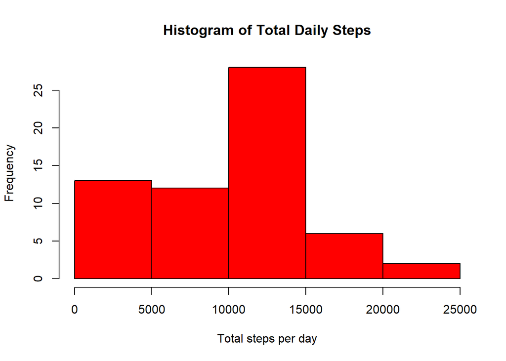

```r
Plot1 <- hist(steps_pd$Total_Steps ,xlab = "Total steps per day", ylab = "Frequency", main = "Histogram of Total Daily Steps", col= "red")
```

```r
summary(steps_pd$Total_Steps)
```

```
##    Min. 1st Qu.  Median    Mean 3rd Qu.    Max.
##       0    6778   10395    9354   12811   21194
```

# Group the data by interval

```r
Avg_Step <- DataSet %>%
     group_by(interval) %>%
     summarise(Average_Steps = mean(steps, na.rm = TRUE))
    print(Avg_Step)
```

#Make a Time series Plot

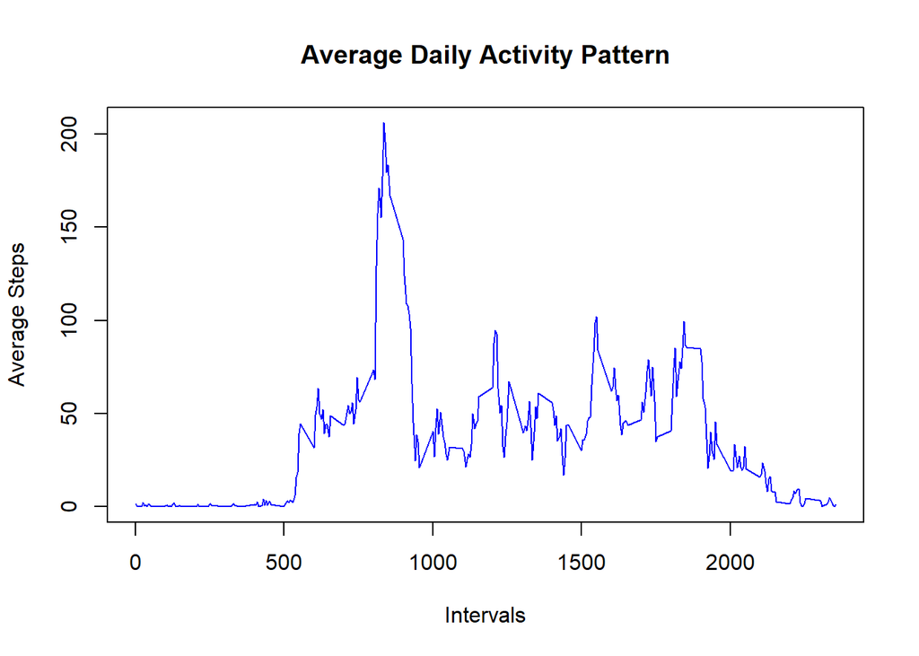

```r
  plot(x = Avg_Step$interval, y = Avg_Step$Average_Steps, type = "l",
  xlab = "Intervals", ylab = "Average Steps", main = "Average Daily Activity Pattern", col   = "blue")
```

#Find which one is the maximum value in interval

```r
which.max(Avg_Step$Average_Steps)
```

```
## [1] 104
```

```r
Avg_Step$Average_Steps[104]
```

```
## [1] 206.1698
```

#Impute missing values

```r
sum(is.na(DataSet$steps))

join_values <- left_join(DataSet,Avg_Step, by = "interval")
join_values <- join_values %>%
mutate(steps_filled = ifelse(is.na(steps), Average_Steps, steps))

print(join_values)
```

#Finding the total of number of steps per day.

```r
  Steps <- join_values %>%
            group_by(date)%>%
            summarise(Total_steps = sum(steps_filled))

          print(Steps)
```

#Ploting a Histogram for the number of steps taken per day. (Calculate and print the mean and median number of total steps per day.)

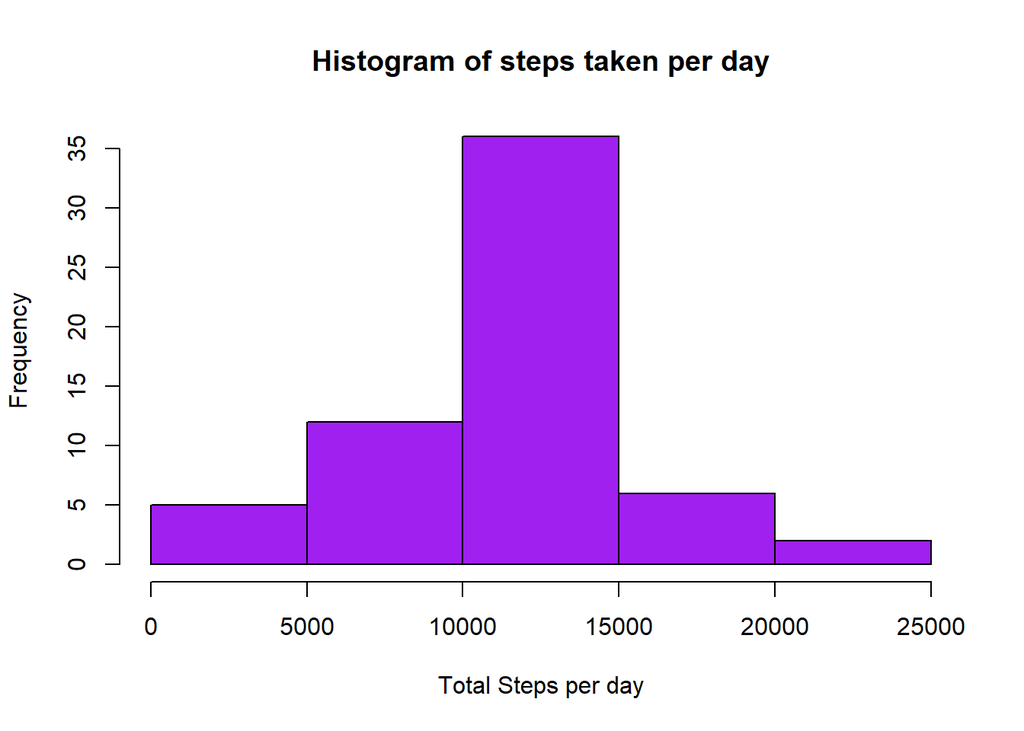

```r
        hist(Steps$Total_steps, xlab = "Total Steps per day", ylab = "Frequency", main = "Histogram of steps taken per day", col = "purple")
```

```r
summary(Steps$Total_steps)
```

```
##    Min. 1st Qu.  Median    Mean 3rd Qu.    Max.
##      41    9819   10766   10766   12811   21194
```